# t4t-final

Allison Davis Connelly

4/4/2022

# Predator Inspection Experiment

## New Data

This will be for the data I collect with Tristan–i.e. the tracking data.

The csv file I created from the current df in our jupyter notebook was waaaay too big to put anywhere. So, I took a few rows and created a testing csv to at least figure out how to do the analyses.

```r
library(curl)
raw.track <- curl("https://raw.githubusercontent.com/allisondavis/t4t_wild-pop/master/testing.csv")

raw.track <- read.csv(raw.track, header = TRUE, sep = ",", stringsAsFactors = TRUE, row.names = NULL)

head(raw.track)
```

```
##   X.1         VY Y.wcentroid     SPEED segment_length detection_class midline_x
## 1   0  0.0000000    29.69107 0.0000000      0.1714321               1  94.19121
## 2   1  0.3745832    29.69163 0.3805694      0.1708874               1  94.20483
## 3   2  0.0000000    29.69163 0.0000000      0.1708874               1  94.20483
## 4   3  0.0000000    29.69163 0.0000000      0.1708874               1  94.20483
## 5   4  4.8823843    29.85427 5.0806975      0.1721395               1  94.22527
## 6   5 -4.5389867    29.87290 4.5391979      0.1500919               1  94.21398
##   timestamp BORDER_DISTANCE.pcentroid midline_y missing ANGULAR_A.centroid
## 1         0                  6.042313  31.62930       0            0.00000
## 2     33333                  6.054504  31.63937       0         -116.02481
## 3     66666                  6.054504  31.63937       0          -75.79881
## 4    100000                  6.054504  31.63937       0          -95.90607
## 5    133333                  6.022888  31.80729       0         -109.83640
## 6    166666                  5.818703  31.59004       0          256.85852
##   normalized_midline ANGULAR_V.centroid    ANGLE MIDLINE_OFFSET        Y
```

[output cut: 20 more lines]

## Old Data

### Boldness data

#### Data collection

```r
library(curl)

raw.bld <- curl("https://raw.githubusercontent.com/allisondavis/t4t_wild-pop/master/bold-raw.csv")

raw.bld <- read.csv(raw.bld, header = TRUE, sep = ",", stringsAsFactors = TRUE)

head(raw.bld)
```

```
##       NAME  SPP BLD1 BLD2 NEO CAST NEU SAFE
## 1     Blue form  144   18  NA   NA  NA   NA
## 2    Cloud form   64   76  NA   NA  NA   NA
## 3 Daffodil form   NA   33  NA   NA  NA   NA
## 4  Jasmine form   64   NA  NA   NA  NA   NA
## 5    Karen form  510   25  NA   NA  NA   NA
## 6   Killua form   37  448  NA   NA  NA   NA
```

```r
#realize that we assigned 600 to fish that never left. Will assign 1000 instead (hopefully to differentiate individuals who exited in 550s from those who never left)

raw.bld$BLD1[raw.bld$BLD1 == 600] <- 1000
raw.bld$BLD2[raw.bld$BLD2 == 600] <- 1000

raw.bld$avg <- rowMeans(raw.bld[, c(3,4)], na.rm = TRUE)

form.bld <- raw.bld[raw.bld$SPP =="form",]
head(form.bld)
```

```
##       NAME  SPP BLD1 BLD2 NEO CAST NEU SAFE   avg
## 1     Blue form  144   18  NA   NA  NA   NA  81.0
## 2    Cloud form   64   76  NA   NA  NA   NA  70.0
## 3 Daffodil form   NA   33  NA   NA  NA   NA  33.0
## 4  Jasmine form   64   NA  NA   NA  NA   NA  64.0
## 5    Karen form  510   25  NA   NA  NA   NA 267.5
## 6   Killua form   37  448  NA   NA  NA   NA 242.5
```

```r
lat.bld <- raw.bld[raw.bld$SPP =="lat",]
head(lat.bld)
```

```
##      NAME SPP BLD1 BLD2 NEO CAST NEU SAFE avg
## 21   Appa lat   29   NA  NA   NA  NA   NA  29
## 22 Carrot lat  153   NA  NA   NA  NA   NA 153
## 23 Edward lat   NA   49  NA   NA  NA   NA  49
## 24  Happy lat  430   NA  NA   NA  NA   NA 430
## 25   Lora lat    7    9  NA   NA  NA   NA   8
## 26   Momo lat   28   NA  NA   NA  NA   NA  28
```

```r
raw.bld.lin <- curl("https://raw.githubusercontent.com/allisondavis/t4t_wild-pop/master/bold-linear-format.csv")

raw.bld.lin <- read.csv(raw.bld.lin, header = TRUE, sep = ",", stringsAsFactors = TRUE)

form.bld.lin <- raw.bld.lin[raw.bld.lin$SPP =="form",]


lat.bld.lin <- raw.bld.lin[raw.bld.lin$SPP =="lat",]
```

*First look*

```r
library(rstatix)
get_summary_stats(form.bld, show = c("mean", "sd", "median", "iqr"))
```

```
## # A tibble: 3 × 6
##   variable     n  mean    sd median   iqr
##   <fct>    <dbl> <dbl> <dbl>  <dbl> <dbl>
## 1 BLD1        19  269.  353.   75    310.
## 2 BLD2        19  194.  307.   60    118.
## 3 avg         20  223.  294.   81.5  201.
```

```r
get_summary_stats(lat.bld, show = c("mean", "sd", "median", "iqr"))
```

```
## # A tibble: 3 × 6
##   variable     n  mean    sd median   iqr
##   <fct>    <dbl> <dbl> <dbl>  <dbl> <dbl>
## 1 BLD1        22  462.  368.   360.  703.
## 2 BLD2        16  420.  426.   263   956.
## 3 avg         23  420.  363.   326   476.
```

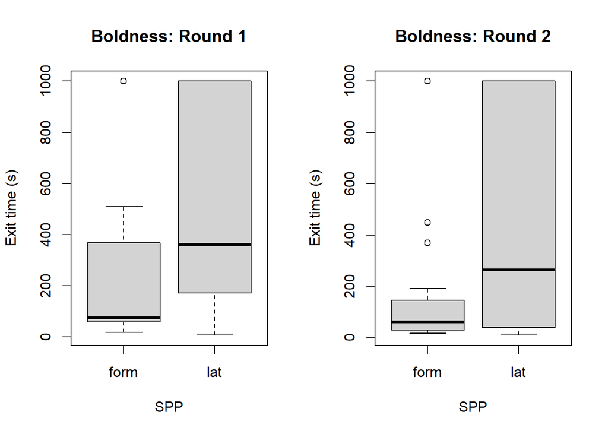

```r
par(mfrow=c(1,2))

boxplot(data=raw.bld, BLD1 ~ SPP, ylab = "Exit time (s)", main= "Boldness: Round 1")

boxplot(data=raw.bld, BLD2 ~ SPP, ylab = "Exit time (s)", main= "Boldness: Round 2")
```

```r
boxplot(data=raw.bld.lin, DURATION ~ ROUND*SPP, ylab = "Exit time (s)", main= "Boldness")


shapiro.test(raw.bld$BLD1)
```

```
##
##  Shapiro-Wilk normality test
##
## data:  raw.bld$BLD1
## W = 0.79696, p-value = 4.723e-06
```

```r
shapiro.test(raw.bld$BLD2)
```

```
##
##  Shapiro-Wilk normality test
##
## data:  raw.bld$BLD2
## W = 0.69852, p-value = 3.533e-07
```

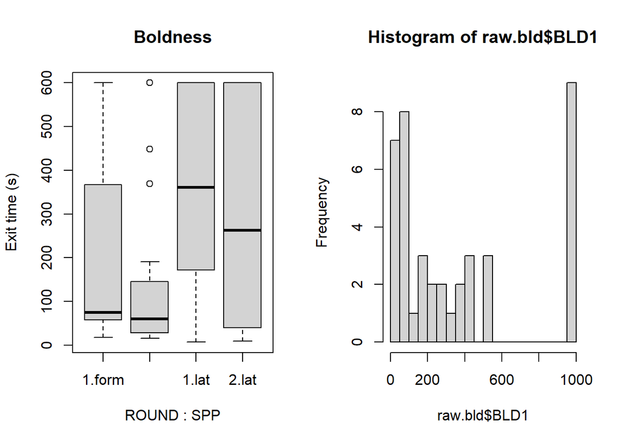

```r
hist(raw.bld$BLD1, breaks=30)
```

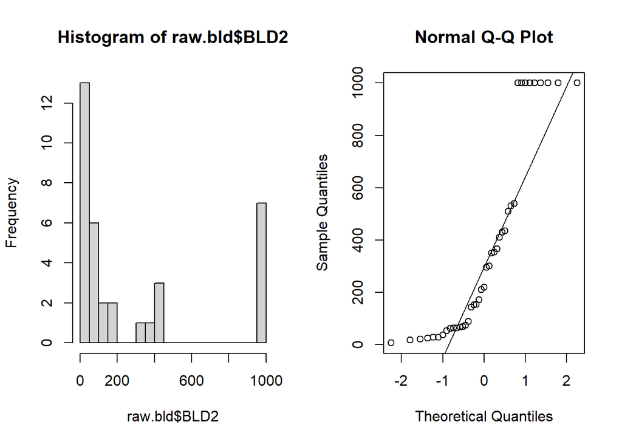

```r
hist(raw.bld$BLD2, breaks=30)

qqnorm(raw.bld$BLD1)
qqline(raw.bld$BLD1)
```

```r
qqnorm(raw.bld$BLD1)
qqline(raw.bld$BLD1)

shapiro.test(raw.bld.lin$DURATION)
```

```
##
##  Shapiro-Wilk normality test
##
## data:  raw.bld.lin$DURATION
## W = 0.8161, p-value = 2.551e-08
```

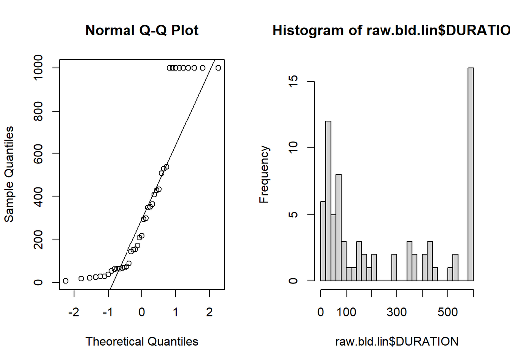

```r
hist(raw.bld.lin$DURATION, breaks=30)
```

```r
qqnorm(raw.bld.lin$DURATION)
qqline(raw.bld.lin$DURATION)

raw.bld <- raw.bld[-c(5:8)]
raw.bld[paste0(names(raw.bld), '_cb')] <- '^'(raw.bld[, 3:5], 1/3)
raw.bld <- raw.bld[-c(6:7)]


shapiro.test(raw.bld$BLD1_cb)
```

```
##
##  Shapiro-Wilk normality test
##
## data:  raw.bld$BLD1_cb
## W = 0.92386, p-value = 0.007203
```

```r
shapiro.test(raw.bld$BLD2_cb)
```

```
##
##  Shapiro-Wilk normality test
##
## data:  raw.bld$BLD2_cb
## W = 0.91647, p-value = 0.005269
```

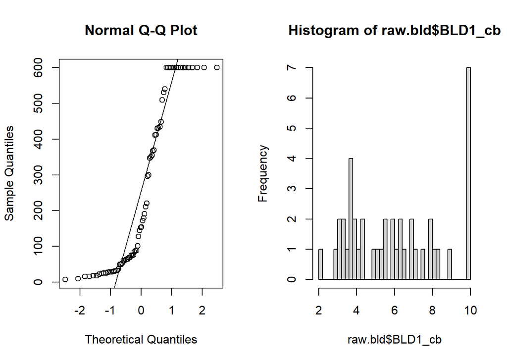

```r
hist(raw.bld$BLD1_cb, breaks=30)
```

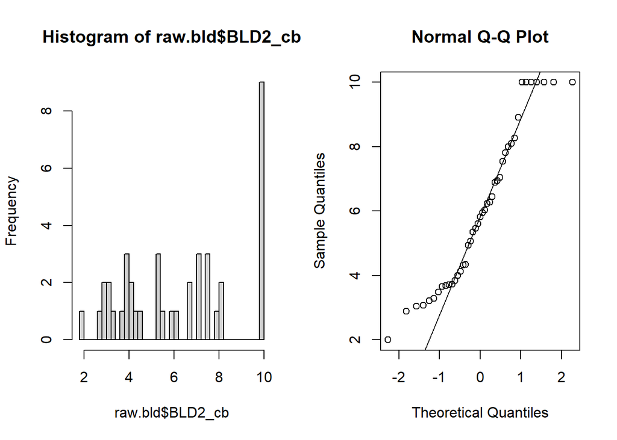

```r
hist(raw.bld$BLD2_cb, breaks=30)

qqnorm(raw.bld$BLD1_cb)
qqline(raw.bld$BLD1_cb)
```

```r
qqnorm(raw.bld$BLD2_cb)
qqline(raw.bld$BLD2_cb)

raw.bld.lin[paste0(names(raw.bld.lin), '_cb')] <- '^'(raw.bld[, 4], 1/3)

shapiro.test(raw.bld.lin$DURATION_cb)
```

```
##
##  Shapiro-Wilk normality test
##
## data:  raw.bld.lin$DURATION_cb
## W = 0.84727, p-value = 5.5e-07
```

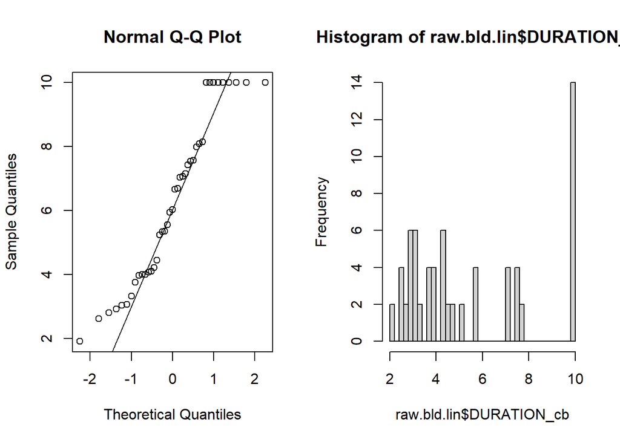

```r
hist(raw.bld.lin$DURATION_cb, breaks=30)
```

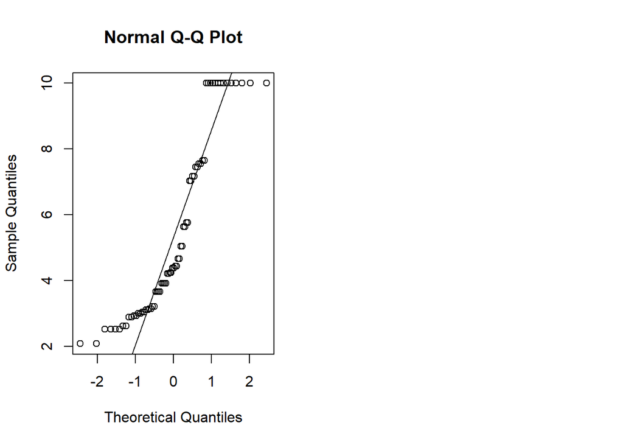

```r
qqnorm(raw.bld.lin$DURATION_cb)
qqline(raw.bld.lin$DURATION_cb)
```

#### Repeatability

Here I will see how repeatable their behavior was from round 1 to round 2

```r
library(ggpubr)
cor.test(form.bld$BLD1, form.bld$BLD2, alternative = "two.sided", method = "pearson", use = "complete.obs")
```

```
##
##  Pearson's product-moment correlation
##
## data:  form.bld$BLD1 and form.bld$BLD2
## t = 3.2726, df = 16, p-value = 0.004788
## alternative hypothesis: true correlation is not equal to 0
## 95 percent confidence interval:
##  0.2361726 0.8490775
## sample estimates:
##       cor
## 0.6332224
```

```r
cor.test(lat.bld$BLD1, lat.bld$BLD2, alternative = "two.sided", method = "pearson", use = "complete.obs")
```

```
##
##  Pearson's product-moment correlation
##
## data:  lat.bld$BLD1 and lat.bld$BLD2
## t = 3.6356, df = 13, p-value = 0.003019
## alternative hypothesis: true correlation is not equal to 0
## 95 percent confidence interval:
##  0.3108257 0.8962933
## sample estimates:
##       cor
## 0.7100338
```

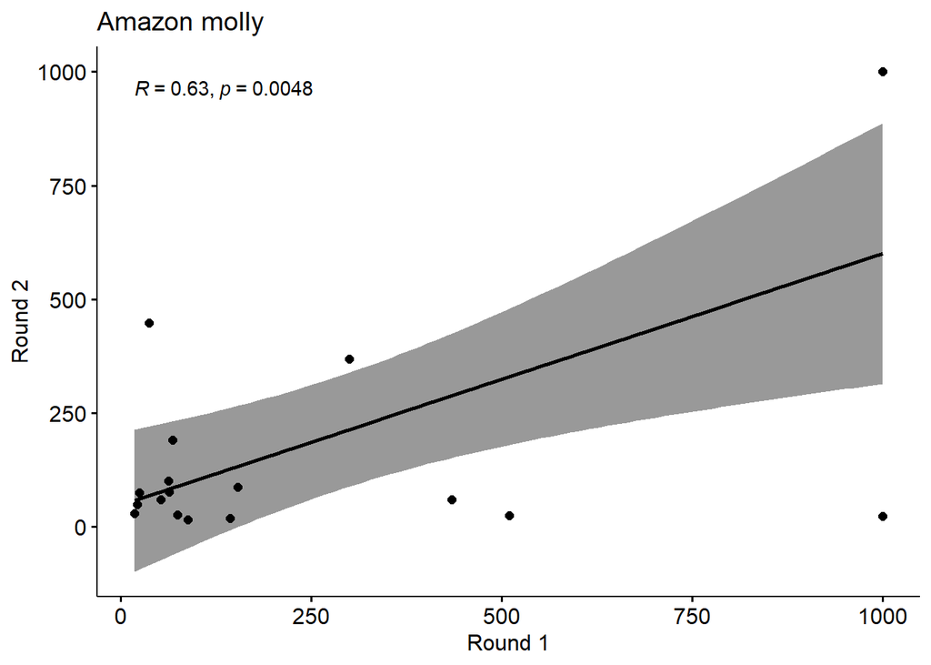

```r
form.cor <- ggscatter(form.bld, x = "BLD1", y = "BLD2", add = "reg.line", conf.int = TRUE, cor.coef = TRUE, cor.method = "pearson", xlab = "Round 1", ylab = "Round 2", main = "Amazon molly")

lat.cor <- ggscatter(lat.bld, x = "BLD1", y = "BLD2", add = "reg.line", conf.int = TRUE, cor.coef = TRUE, cor.method = "pearson", xlab = "Round 1", ylab = "Round 2", main = "Sailfin molly")


par(mfrow=c(1,2))
form.cor
```

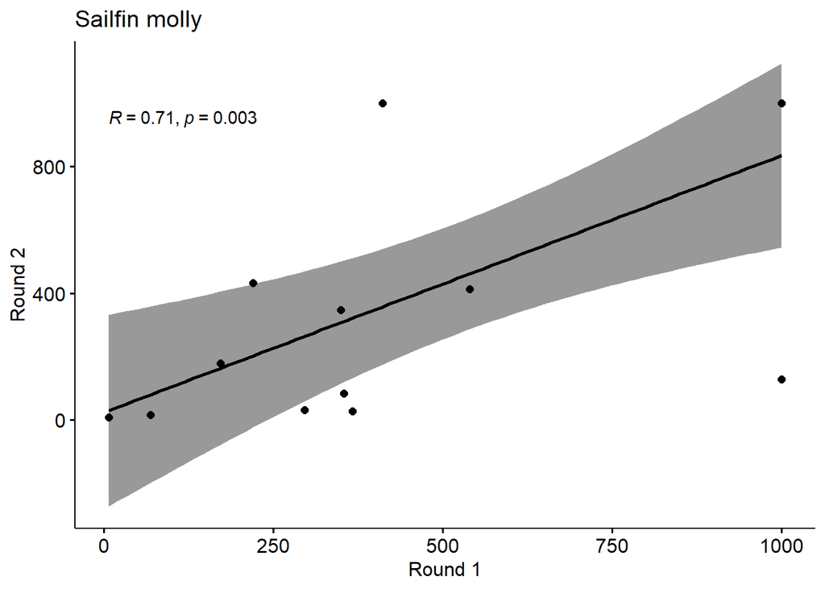

```r
lat.cor
```

```r
###TRANSFORMED DATA

form.bld <- raw.bld[raw.bld$SPP =="form",]
head(form.bld)
```

```
##       NAME  SPP BLD1 BLD2   avg  BLD1_cb  BLD2_cb   avg_cb
## 1     Blue form  144   18  81.0 4.326749 5.241483 2.620741
## 2    Cloud form   64   76  70.0 4.121285 4.000000 4.235824
## 3 Daffodil form   NA   33  33.0 3.207534       NA 3.207534
## 4  Jasmine form   64   NA  64.0 4.000000 4.000000       NA
## 5    Karen form  510   25 267.5 6.443294 7.989570 2.924018
## 6   Killua form   37  448 242.5 6.235969 3.332222 7.651725
```

```r
lat.bld <- raw.bld[raw.bld$SPP =="lat",]
head(lat.bld)
```

```
##      NAME SPP BLD1 BLD2 avg  BLD1_cb  BLD2_cb   avg_cb
## 21   Appa lat   29   NA  29 3.072317 3.072317       NA
## 22 Carrot lat  153   NA 153 5.348481 5.348481       NA
## 23 Edward lat   NA   49  49 3.659306       NA 3.659306
## 24  Happy lat  430   NA 430 7.547842 7.547842       NA
## 25   Lora lat    7    9   8 2.000000 1.912931 2.080084
## 26   Momo lat   28   NA  28 3.036589 3.036589       NA
```

```r
cor.test(form.bld$BLD1_cb, form.bld$BLD2_cb, alternative = "two.sided", method = "pearson", use = "complete.obs")
```

```
##
##  Pearson's product-moment correlation
##
## data:  form.bld$BLD1_cb and form.bld$BLD2_cb
## t = 8.9914, df = 17, p-value = 7.183e-08
## alternative hypothesis: true correlation is not equal to 0
## 95 percent confidence interval:
##  0.7745767 0.9648415
## sample estimates:
##       cor
## 0.9089864
```